# Violence in Mexico

Mariana Meza Hernandez

February 13, 2019

```r
# load the datasets with direct paths
causegraph <- read_csv("~/Mariana Meza Hernandez/Harris/Winter 19/Data Visualiaztion/HW5/Data/causegraph.csv")
homicide <- read_csv("~/Mariana Meza Hernandez/Harris/Winter 19/Data Visualiaztion/HW5/Data/homicide_snsp_month.csv")
test <- read_csv("~/Mariana Meza Hernandez/Harris/Winter 19/Data Visualiaztion/HW5/Data/difftrendssnspinegi.csv")
rank_states <- read_csv("~/Mariana Meza Hernandez/Harris/Winter 19/Data Visualiaztion/HW5/Data/homicideraterankstate2.csv")
incidencia <- (read_csv("~/Mariana Meza Hernandez/Harris/Winter 19/Data Visualiaztion/HW5/Data/denunciados_incidencia.csv"))
insecurity <- read_csv("~/Mariana Meza Hernandez/Harris/Winter 19/Data Visualiaztion/HW5/Data/insecurityperception.csv")
mexstates <- (st_as_sf(ne_states(country = "mexico")))
sankey <- read_csv("~/Mariana Meza Hernandez/Harris/Winter 19/Data Visualiaztion/HW5/Data/sankey_graph_v2.csv")
mosaico <- list.files("~/Mariana Meza Hernandez/Harris/Winter 19/Data Visualiaztion/HW5/Data/mosaic", pattern = ".png", full.names = TRUE)
moran <- list.files("~/Mariana Meza Hernandez/Harris/Winter 19/Data Visualiaztion/HW5/Data/moran", pattern = ".png", full.names = TRUE)
```

## Homicide by firearm by month and year

Even though one cannot confirm causality between both events, it is clear that the level of homicides by firearm in Mexico increased dramatically since the start of the war against organized crime in early 2007. Over the last decades the number of homicides by firearm have remained almost four time higher than before the war began.

```r
homicide_long <- gather (homicide, month, homicides, January:December, factor_key = TRUE)
```

```r
month_year_gun <-
  homicide_long %>%
  filter(subtype == "CON ARMA DE FUEGO") %>%
  filter (year > "2000") %>%
  group_by(year, month) %>%
  summarize(total_gun = sum(homicides))
```

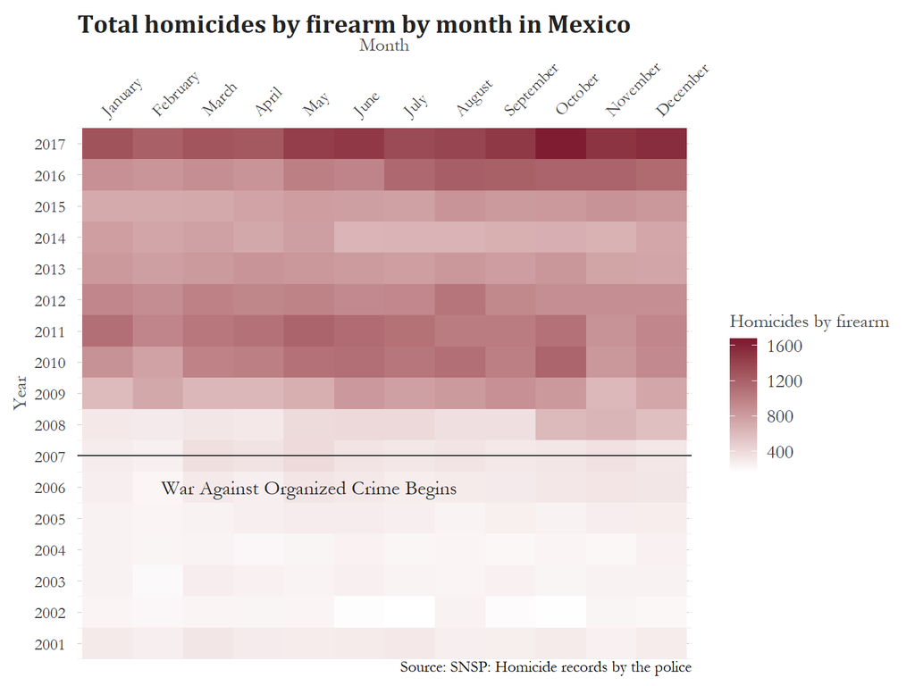

```r
mycols3 <- c("#7f1c32", "#2f2016", "#fcfaea", "#456789")
ggplot(data = month_year_gun) +
  geom_tile(aes(x = month, y =year, fill = total_gun)) +
  scale_y_continuous(breaks = 1997:2017, expand = c(0,0)) +
  scale_x_discrete(position = "top") +
  theme_mmh()+
  theme(axis.text.x = element_text(angle = 45, hjust = 0)) +
  geom_hline(aes(yintercept=2007), color="#222222") +
  scale_fill_gradient(low = "white", high = "#7f1c32") +
  ggtitle("Total homicides by firearm by month in Mexico") +
  labs(x = "Month", y = "Year", fill= "Homicides by firearm", caption = "Source: SNSP: Homicide records by the police", family= "Garamond")  +
   annotate("text", x = "May", y = 2006, label = "War Against Organized Crime Begins", size = 4.5, color = "#222222", family = "Garamond")
```

## Difference between police reports and death certificates

The two main data sources that report homicides in Mexico are the homicide records by the police (SNSP) and the mortality statistics by the autonomous statistic institute (INEGI). In order to understand the violence in Mexico we need to look at both. One of the most interesting phenomena is that since the war against organized crime began, the trends in total violent homicides of both sources flipped. Since 2007, police reports have systematically undereported homicides in Mexico.

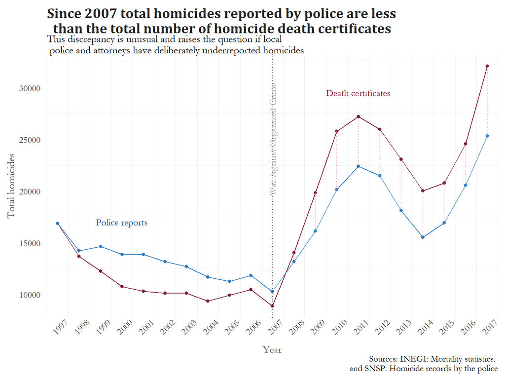

```r
ggplot(test, aes(x=Year, y = total, group=type))+
 geom_line(aes(color=type)) +
 geom_point(aes(color=type)) +
  theme_mmh()+
  theme(axis.text.x = element_text(angle = 45),
        panel.grid.major = element_blank(),
        legend.position = "none")+
  scale_color_manual(values=c("#7f1c32", "#2d7ac1"),
                     name = "Homicide records according to",
                     breaks = c("death_certificates", "police_reports"),
                     labels = c("Death certificates","Police reports"))+
  labs(x = "Year", y = "Total homicides" , subtitle = "This discrepancy is unusual and raises the question if local \n police and attorneys have deliberately underreported homicides", caption = "Sources: INEGI: Mortality statistics. \n and SNSP: Homicide records by the police") +

  xlab("Year") +
  ggtitle("Since 2007 total homicides reported by police are less \n  than the total number of homicide death certificates") +
  geom_vline(xintercept = 2007, linetype="dotted")+
  annotate("segment", x = 2008, xend = 2008, y = 13155, yend = 14006,
  colour = "#ff85a0", linetype= "dotted")+
  annotate("segment", x = 2009, xend = 2009, y = 16118, yend = 19803,
  colour = "#ff85a0", linetype= "dotted")+
  annotate("segment", x = 2010, xend = 2010, y = 20143, yend = 25757,
  colour = "#ff85a0", linetype= "dotted")+
  annotate("segment", x = 2011, xend = 2011, y = 22409, yend = 27213,
  colour = "#ff85a0", linetype= "dotted")+
  annotate("segment", x = 2012, xend = 2012, y = 21459, yend = 25976,
  colour = "#ff85a0", linetype= "dotted")+
  annotate("segment", x = 2013, xend = 2013, y = 18106, yend = 23063,
  colour = "#ff85a0", linetype= "dotted")+
  annotate("segment", x = 2014, xend = 2014, y = 15520, yend = 20010,
  colour = "#ff85a0", linetype= "dotted")+
  annotate("segment", x = 2015, xend = 2015, y = 16909, yend = 20762,
  colour = "#ff85a0", linetype= "dotted")+
  annotate("segment", x = 2016, xend = 2016, y = 20547, yend = 24559,
  colour = "#ff85a0", linetype= "dotted")+
  annotate("segment", x = 2017, xend = 2017, y = 25339, yend = 32079,
  colour = "#ff85a0", linetype= "dotted")+
  annotate("text", x = 2007, y = 25000, label = "War Against Organized Crime", angle=90, family = "Garamond", color = "darkgrey" ) +
  annotate("text", x = 2000, y = 17000, label = "Police reports",  family = "Garamond", color = "dodgerblue4" ) +
  annotate("text", x = 2011, y = 29500, label = "Death certificates",  family = "Garamond", color = "darkred" ) +
  scale_x_continuous(breaks = 1997:2017, expand = c(0,0.5))
```

## Homicide rates by state through the years

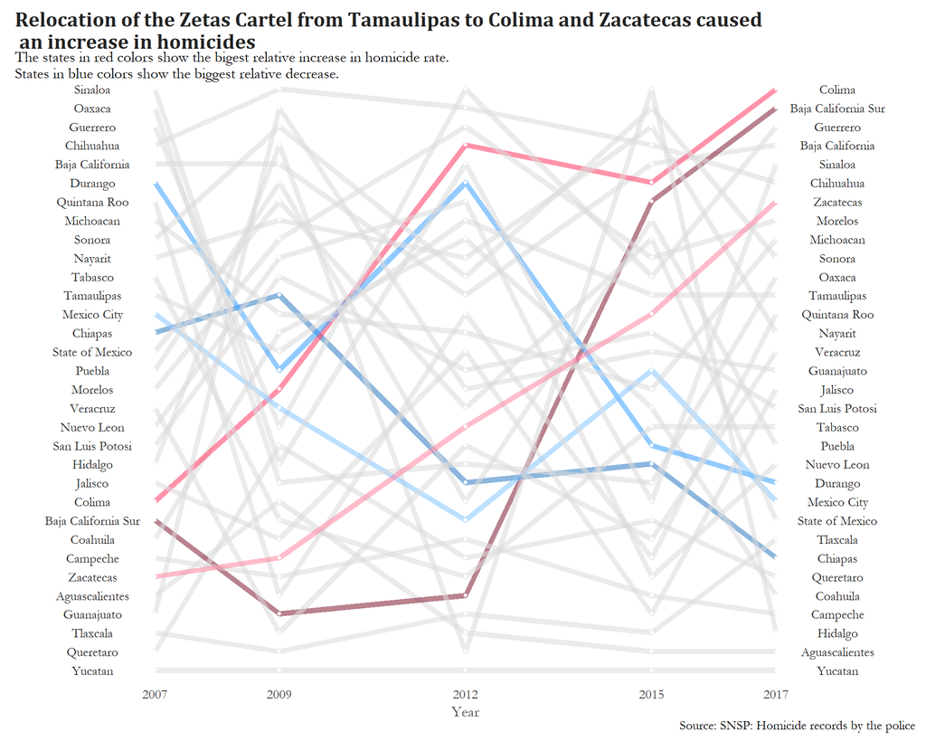

```r
colors <- c("#DBDBDB","#DBDBDB","#7f1c32","#DBDBDB","#2d7ac1","#DBDBDB","#DBDBDB","#ff3864","#3ba1ff","#DBDBDB","#DBDBDB","#DBDBDB","#DBDBDB","#87c6ff","#DBDBDB","#DBDBDB","#DBDBDB","#DBDBDB","#DBDBDB","#DBDBDB","#DBDBDB","#DBDBDB","#DBDBDB","#DBDBDB","#DBDBDB","#DBDBDB","#DBDBDB","#DBDBDB","#DBDBDB","#DBDBDB","#DBDBDB","#ff85a0")
ggplot(data = rank_states, aes(x = year, y = rank, group = states)) +
  geom_line(aes(color = states, alpha = 1), size = 2) +
  geom_point(aes(color = states, alpha = 1), size = 1) +
  scale_y_reverse(breaks = 1:nrow(rank_states), expand = c(0,0.5))+
  geom_point(color = "#FFFFFF", size = 1)+
  scale_x_continuous(breaks = c(2007,2009,2012,2015,2017), expand = c(0.1,0.05))+
  geom_text(data=rank_states %>% filter(year=="2007"),
            aes(label=states, x=2006), size=3.5, family = "Garamond", color = "#222222")+
  geom_text(data = rank_states %>% filter(year == "2017"),
            aes(label = states, x = 2018) , size = 3.5, family = "Garamond", color = "#222222") +
  coord_cartesian(ylim = c(1,32)) +
  theme_mmh() +
  theme(legend.position = "none",
        axis.title.y=element_blank(),
        plot.title = element_text(hjust=0),
        plot.subtitle = element_text(hjust=0),
        axis.text.y=element_blank(),
        axis.ticks.y=element_blank(),
        panel.grid.major = element_blank(),
        panel.grid.minor = element_blank()) +
  scale_color_manual(values = colors)+
  labs(x = "Year",
       title = "Relocation of the Zetas Cartel from Tamaulipas to Colima and Zacatecas caused \n an increase in homicides",
       subtitle = "The states in red colors show the bigest relative increase in homicide rate.\nStates in blue colors show the biggest relative decrease.", caption = "Source: SNSP: Homicide records by the police", family = "Garamond")
```

## Municipalities by level of violence

The municipalities with the largest homicide rates per 100,000 are located in the West and Southeast regions of the country. The Northwest region comes in a third place. The graph shows how homicides are concentrated in particular very violent municipalities in each region. A targeted security policy in those municipalities is key.

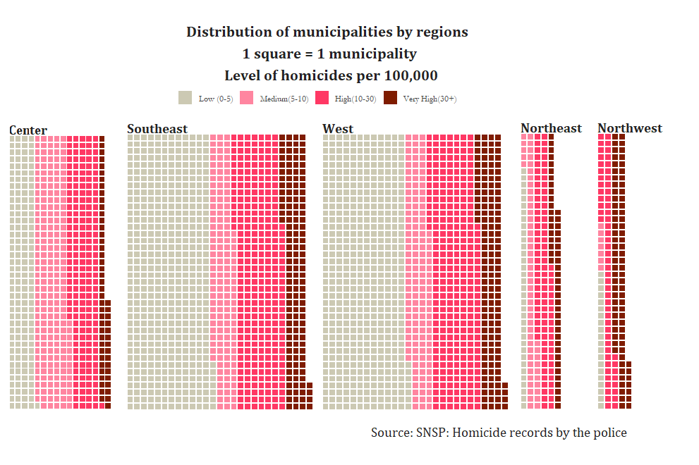

```r
knitr:: include_graphics(mosaico)
```

## Spatial autocorrelation of homicide levels between municipalities

One of the most important measures of spatial correlation is Local Moran’s I. Local Moran’s I measures how geographical units can form statistically significant clusters. A positive value for Moran’s I indicates that a feature has neighboring features with similarly high or low attribute values; this feature is part of a cluster. In this case the dark red or dark blue clusters are clusters with similar neighbors. A negative value for I indicates that a feature has neighboring features with dissimilar values; this feature is an outlier. For the case of the municipalities, the light red and light blue are clusters with dissimilar neighbors.

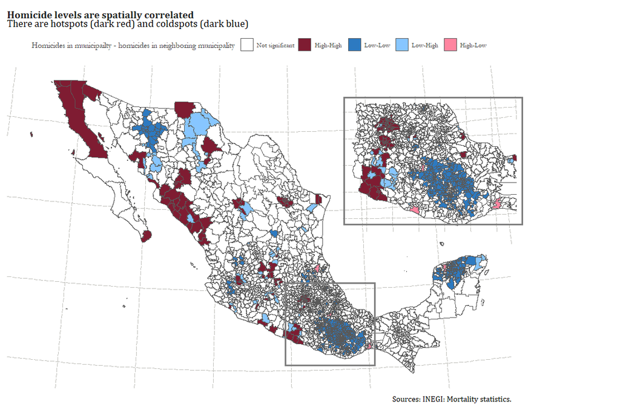

```r
include_graphics(moran)
```

## Perception of insecurity in states

When people are asked to describe the level of insecurity of their state, their perception varies significantly from state to state.

```r
mexstates <- left_join(mexstates, insecurity)
mexstates[12,86] = 3
```

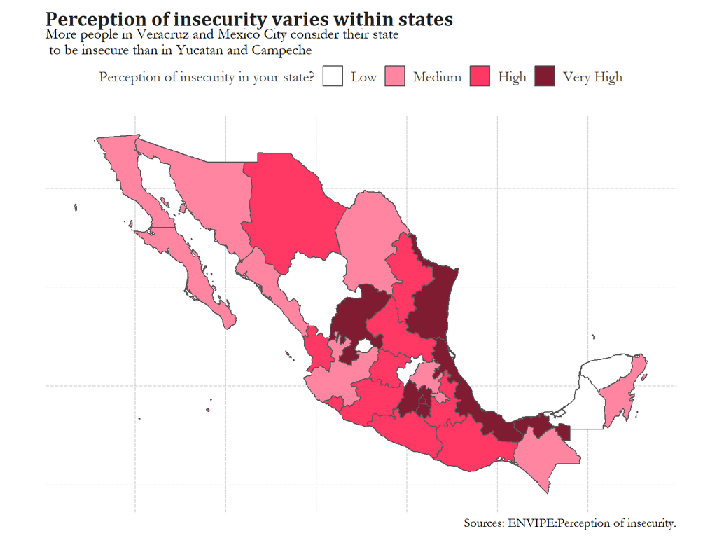

```r
ggplot(mexstates, aes(fill=factor(rank_perc))) +
  geom_sf() +
  scale_fill_manual(breaks = c(1,2,3,4),
                    labels = c("Low", "Medium", "High","Very High"),
                        values=c("white", "#ff85a0", "#ff3864", "#7f1c32")) +
  labs(title="Perception of insecurity varies within states",
       fill = "Perception of insecurity in your state?",
       caption = "Sources: ENVIPE:Perception of insecurity.",
       subtitle = "More people in Veracruz and Mexico City consider their state \n to be insecure than in Yucatan and Campeche")+
  theme_mmh()+
  theme(axis.title.x=element_blank(),
        plot.title = element_text(hjust = 0),
        axis.text.x=element_blank(),
        axis.ticks.x=element_blank(),
        axis.text.y = element_blank(),
        axis.ticks.y = element_blank(),
        legend.position = "top")
```

## Cause of homicide by sex

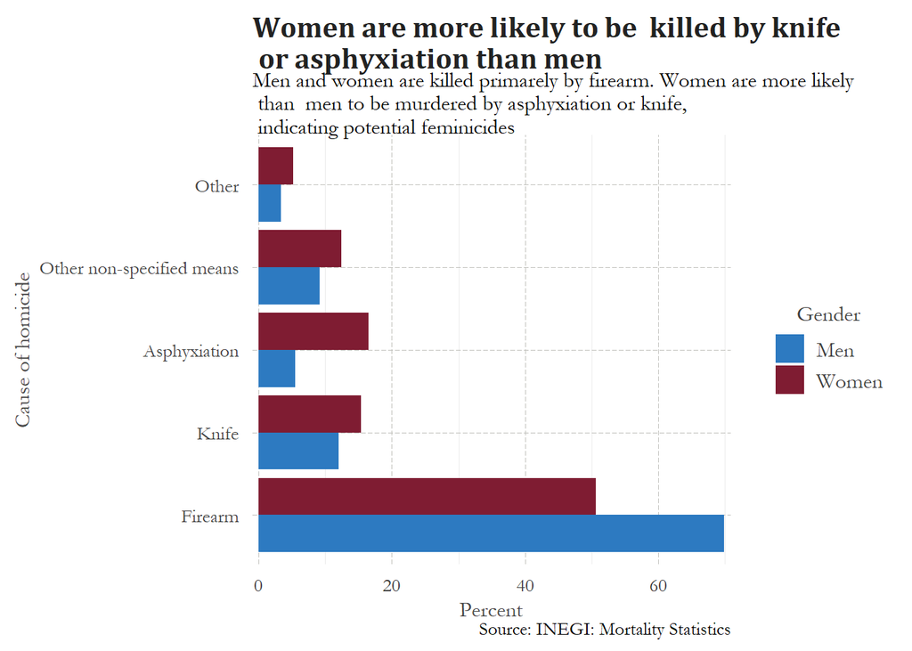

```r
ggplot(causegraph) +
geom_bar(mapping = aes(x = reorder(cause3, -percent), y = percent, group = sexo2, fill = factor(sexo2)),stat = "identity", position = "dodge")+ coord_flip() +
  scale_y_continuous(expand = c(0,1))+
  scale_fill_manual ("Gender", values = c("Men" = "#2d7ac1", "Women" = "#7f1c32")) +
  labs(x = "Cause of homicide", y = "Percent", subtitle = "Men and women are killed primarely by firearm. Women are more likely \n than  men to be murdered by asphyxiation or knife,\n indicating potential feminicides", caption = "Source: INEGI: Mortality Statistics") +
  ggtitle("Women are more likely to be  killed by knife \n or asphyxiation than men") +
  guides(fill=guide_legend("Gender")) +
  theme_mmh()
```

## Place of homicide and relationship to killer by gender

Another difference between men and women is that most women are killed at home, regardless if they are killed by a relative or not. Furthermore, more women are killed by relatives than strangers. In contrast, men are killed predominantly in the streets either by relatives or strangers.

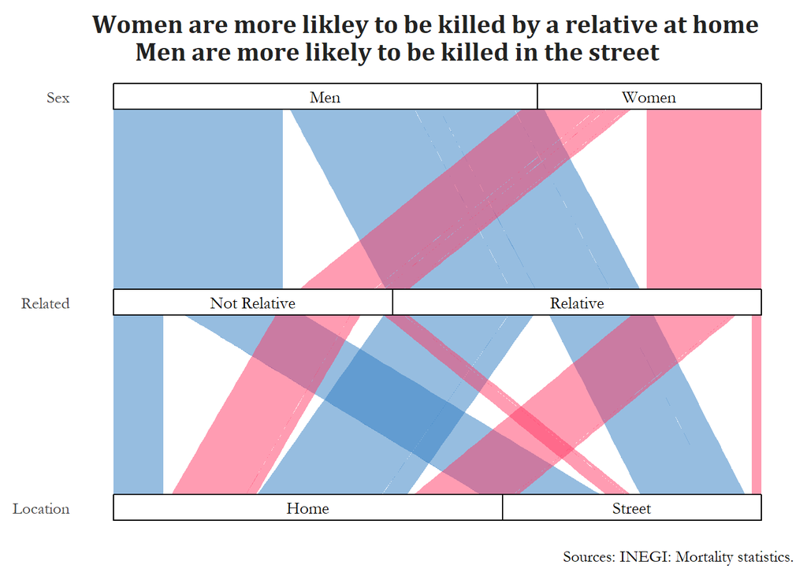

```r
colors <- c("#2d7ac1", "#ff3864", "#ccc9b3")
ggplot(sankey,
       aes(y = freq,
          axis1 = location, axis2 = related, axis3 = sexo)) +
  geom_alluvium(aes(fill = sexo),
                width = 0, knot.pos = 0, reverse = FALSE) +
  guides(fill = FALSE) +
  geom_stratum(width = 1/8, reverse = FALSE) +
  geom_text(stat = "stratum", label.strata = TRUE, reverse = FALSE, family = "Garamond") +
  scale_x_continuous(breaks = 1:3, labels = c("Location", "Related", "Sex")) +
  coord_flip() +
  ggtitle("  Women are more likley to be killed by a relative at home
          Men are more likely to be killed in the street")+
  theme_mmh()+
  theme(
        axis.title.x=element_blank(),
        axis.text.x=element_blank(),
        axis.ticks.x=element_blank(),
        panel.grid.major = element_blank(),
        panel.grid.minor = element_blank(),
  ) +
  labs(caption = "Sources: INEGI: Mortality statistics.") +
  scale_fill_manual(values = colors)
```